# Un análisis a los universitarios ¿Quieren maestría/doctorado?

2025-03-29

Analicemos acerca de la muestra aleatoria con la que contamos, donde buscamos ver que de los 400 estudiantes encuestados, ver los que sí tienen algún interés en aplicar una maestría o doctorado, al igual que sobre los que no tengan interés.

Como primera parte de este análisis, presentemos una gráfica donde podremos ver cómo se distribuye la frecuencia de las respuestas, tomando en cuenta el tipo de universidad del que vienen, así como ver si sus padres cursaron algún tipo de posgrado.

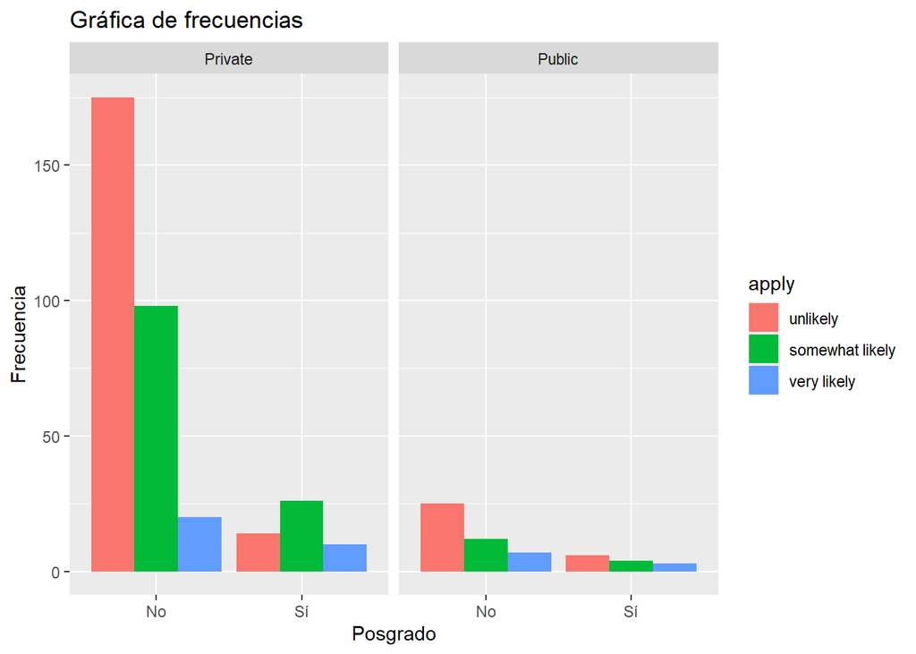

En base a la gráfica presentada para empezar notamos como la proporción de los estudiantes preguntados fueron en mayor medida de escuelas privadas.

Posteriormente, podemos notar una clara tendencia sobre todo en aquellos que estudiaron en escuela privada y que sus padres no han tomado algún tipo de posgrado, con una obvia tendencia a que no es probable que tomen alguna maestría o doctorado. Es más, podemos ver que en la mayoría de las 4 categorías es más probable que no se tome algún estudio extra, el único caso donde es más probable que sí se tome es para aquellos que son de escuelas privadas y sus padres sí tomaron algún posgrado, esto a priori tiene sentido pues como son de escuelas privadas, podemos pensar que cuentan con el capital para hacerlo y ven a sus padres con algún posgrado y quieren seguir sus pasos.

Ya habiendo analizado las interacciones entre estudiantes con diferente tipo de escuela y diferente tipo de estudio de los padres, ahora analicemos en base al rendimiento que tienen estos.

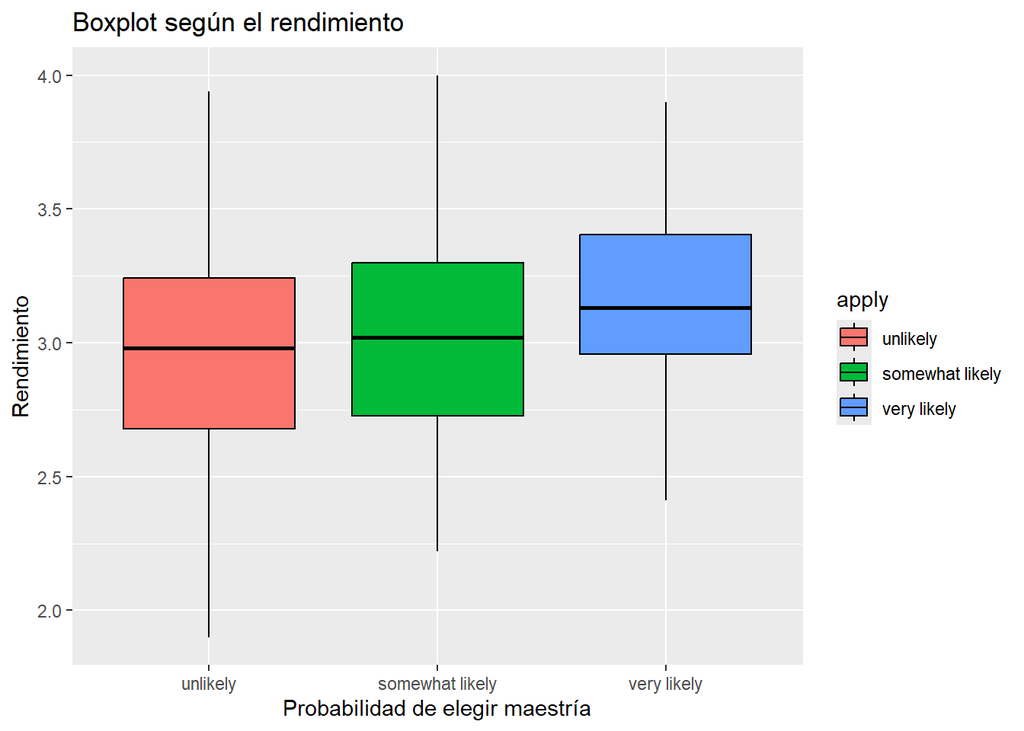

En este caso, tenemos que los resultados no se disparan de una forma tan evidente como por ejemplo en el gráfico anterior, pero sí podemos observar que aquellos que tienen una mejor media en su rendimiento académico tienden más hacia sí querer cursar una maestría o doctorado, mientras que los que menos quieren tomar esto son aquellos donde su media es menor. Esto tiene sentido porque aquellos que tienen mejor rendimiento académico querrán enriquecerse de más conocimiento, mientras que los que tienen un rendimiento académico menor, es menos probable que quieran extender sus conocimientos de esta forma.

Ahora analizaremos el modelo con interacciones y sin interacciones y después decidiremos con qué modelo nos quedaremos.

Como medida extra, veamos el AIC del modelo completo, así como del modelo reducido, para ver si podemos fortalecer más nuestras conclusiones.

```
## [1] "El AIC del modelo considerando interacciones es:  733.164814450684"
```

```
## [1] "El AIC del modelo sin considerar interacciones es:  729.993963187879"
```

Viendo que, en efecto, nos ayuda a tomar una conclusión, donde el AIC del modelo sin interacciones es mejor, por lo que nos quedaremos de momento con el modelo sin interacciones.

Ahora, como tenemos respuestas que van desde el muy probable, al probable hasta el poco probable, estamos lidiando con un modelo ordinal, donde según la respuesta, tiene mayor o menor peso que las otras según lo que queremos ver, entonces si hacemos un análisis tenemos que, al no tomar en cuenta las probabilidades proporcionales y después considerando las probabilidades proporcionales analizaremos esto y veremos con qué modelo nos quedamos.

Como extra complementario, veamos los AIC del modelo considerando proporcionalidad y sin considerarla, para poder tener una decisión más clara.

```
## [1] "El AIC del modelo considerando proporcionalidad es:  727.024871327812"
```

```
## [1] "El AIC del modelo sin considerar proporcionalidad es:  729.011112767812"
```

Coincidiendo en que el modelo considerando proporcionalidad tiene un AIC mejor que el que no considera proporcionalidad, por lo que nos quedaremos con el modelo que sí considera proporcionalidad.

Ahora, contamos con dos posibles modelos para usar, para poder tomar una decisión de si tomar el modelo reducido del inicio o el modelo con probas proporcionales que acabamos de elegir, veamos los AIC.

```
##   Nominal ProbaProp
## 1 729.994  727.0249
```

Al tener que se calculan de diferente forma tanto el modelo nominal como el ordinal, vemos que, gracias a los AIC, el del modelo con probabilidades proporcionales es mejor, decidiendo entonces que, en nuestro caso este es el modelo que usaremos.

Por lo que nos quedaría lo siguiente:

$$\beta_{0}^{(i)} +
\beta_{1}X_{ConPosgrado} + \beta_{2}X_{EscuelaPública} +
\beta_{3}X_{GPA}$$

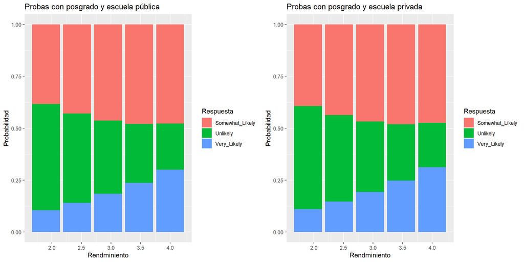

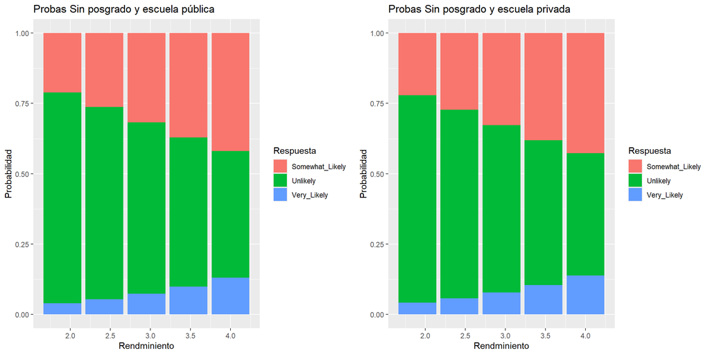

Podemos ver que, tanto para aquellos que estuvieron en escuela pública como en escuela privada donde en ningún caso alguno de sus padres cursó algún posgrado, sus hijos no tienen tanto interés en cursar alguno, pues podríamos atribuirlo a que como sus padres no tienen, a ellos no les parecerá tan importante, por lo que es significativo tomar en cuenta si los padres tomaron algún posgrado.

Por otro lado, vemos que aquellos estudiantes cuyos padres cursaron algún tipo de posgrado (tanto para aquellos de escuelas privadas como para los de pública), tienen un mayor interés en cursar un posgrado, posiblemente se deba a que como sus padres cursaron alguno, al llegar a esta etapa les habrán inculcado la importancia y relevancia de cursar uno.

Y finalmente, podemos ver que, en cuanto mejor rendimiento tenga el estudiante, más probable es que quiera cursar algún posgrado. Para todos los casos podemos ver que el tipo de escuela es un aspecto que no tiene tanta relevancia como los otros casos que mencionamos.